# Part II - (Ford GoBike System Data - Explanation)

## by Aristide FOTSO

## Dataset Overview

> There are 175,147 items in the dataset with 8 features (trip_duration(s), member_birth_year, time, date, user_type, member_gender, AgeGroup, bike_share_for_all_trip). Most variables are float and integer in nature, but the variables AgeGroup, member_gender, bike_share_for_all_trip, and user_type are ordered factor variables with the following levels.

> (worst) ——> (best)
> - bike_share_for_all_trip: No, Yes
> - user_type: Customer, Subscriber
> - member_gender: Other, Female, Male
> - AgeGroup: very_young, young, midlife, old, very_old

## Distribution of trip duration

> trip duration in the dataset take on a very large range of values, from about 0 𝑎𝑡 𝑡ℎ𝑒 𝑙𝑜𝑤𝑒𝑠𝑡,𝑡𝑜 𝑎𝑏𝑜𝑢𝑡 85,000 at the highest. Plotted on a logarithmic scale, the distribution of trip duration takes on a unimodal shape.

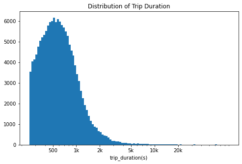

## Distribution of Number of Trips Per Day of Week

> In this distribution, we can see that there are more trips on Tuesday and Thursday

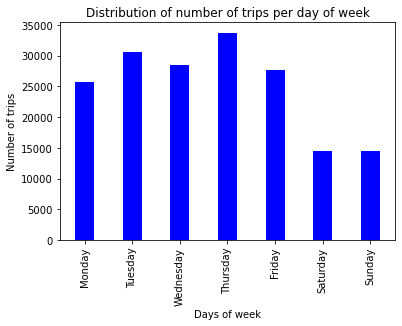

## Distribution of Number of Trips per Hour of day

> In this distribution, we can see that there are more trips on periods: from **07:00 am to 09:00 am** and from **03:00 pm to 05:00 pm**

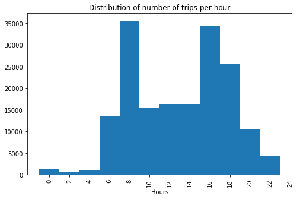

## Relationship between number of trips, days of week, age group, user type

> We can see that users in old and midlife age groups made more trips , and on Tuesday and Thursday

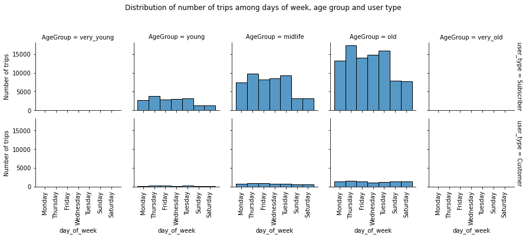

## Relationship between number of trips, hours of day, age group, user type

> We can see that users in old and midlife age groups made more trips, and between 08:00 am and 10:00 am, 04:00 pm and 06:00 pm

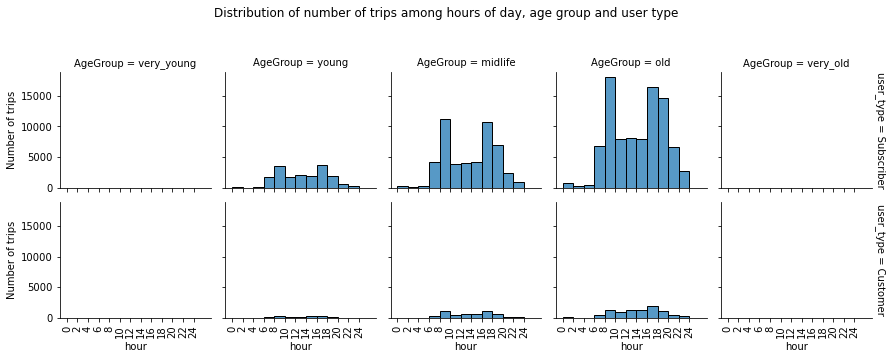

## Relationship between trip duration, age group and gender of user

We can see that users in old and midlife age groups spent more time in trips than other age groups no matter gender of user

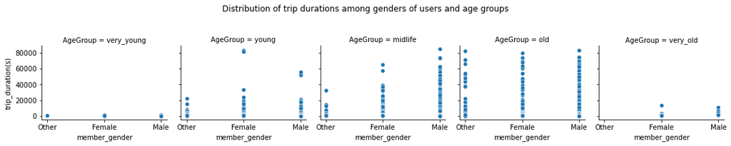